# NYC_Bikes

```python
import pandas as pd
import numpy as np
import matplotlib.pyplot as plt
```

```python
data=pd.read_csv("NYC_Bicycle_Counts_2016_Corrected.csv")
data.head()
```

|  | Date | Day | High Temp (°F) | Low Temp (°F) | Precipitation | Brooklyn Bridge | Manhattan Bridge | Williamsburg Bridge | Queensboro Bridge | Total |
| --- | --- | --- | --- | --- | --- | --- | --- | --- | --- | --- |
| 0 | 1-Apr | Friday | 78.1 | 66.0 | 0.01 | 1,704 | 3,126 | 4,115 | 2,552 | 11,497 |
| 1 | 2-Apr | Saturday | 55.0 | 48.9 | 0.15 | 827 | 1,646 | 2,565 | 1,884 | 6,922 |
| 2 | 3-Apr | Sunday | 39.9 | 34.0 | 0.09 | 526 | 1,232 | 1,695 | 1,306 | 4,759 |
| 3 | 4-Apr | Monday | 44.1 | 33.1 | 0.47 (S) | 521 | 1,067 | 1,440 | 1,307 | 4,335 |
| 4 | 5-Apr | Tuesday | 42.1 | 26.1 | 0 | 1,416 | 2,617 | 3,081 | 2,357 | 9,471 |

**Data Pre-Processing**

```python
#created new month colum form date
mon=[]
for i in range(len(data['Date'])):
    mon.append(data["Date"][i].split("-")[1])
data['Month']=mon
data.head()
```

|  | Date | Day | High Temp (°F) | Low Temp (°F) | Precipitation | Brooklyn Bridge | Manhattan Bridge | Williamsburg Bridge | Queensboro Bridge | Total | Month |
| --- | --- | --- | --- | --- | --- | --- | --- | --- | --- | --- | --- |
| 0 | 1-Apr | Friday | 78.1 | 66.0 | 0.01 | 1,704 | 3,126 | 4,115 | 2,552 | 11,497 | Apr |
| 1 | 2-Apr | Saturday | 55.0 | 48.9 | 0.15 | 827 | 1,646 | 2,565 | 1,884 | 6,922 | Apr |
| 2 | 3-Apr | Sunday | 39.9 | 34.0 | 0.09 | 526 | 1,232 | 1,695 | 1,306 | 4,759 | Apr |
| 3 | 4-Apr | Monday | 44.1 | 33.1 | 0.47 (S) | 521 | 1,067 | 1,440 | 1,307 | 4,335 | Apr |
| 4 | 5-Apr | Tuesday | 42.1 | 26.1 | 0 | 1,416 | 2,617 | 3,081 | 2,357 | 9,471 | Apr |

```python
#update data column
dt=[]
for i in range(len(data['Date'])):
    dt.append(int(data["Date"][i].split("-")[0]))
data['Date']=dt
data.head()
```

|  | Date | Day | High Temp (°F) | Low Temp (°F) | Precipitation | Brooklyn Bridge | Manhattan Bridge | Williamsburg Bridge | Queensboro Bridge | Total | Month |
| --- | --- | --- | --- | --- | --- | --- | --- | --- | --- | --- | --- |
| 0 | 1 | Friday | 78.1 | 66.0 | 0.01 | 1,704 | 3,126 | 4,115 | 2,552 | 11,497 | Apr |
| 1 | 2 | Saturday | 55.0 | 48.9 | 0.15 | 827 | 1,646 | 2,565 | 1,884 | 6,922 | Apr |
| 2 | 3 | Sunday | 39.9 | 34.0 | 0.09 | 526 | 1,232 | 1,695 | 1,306 | 4,759 | Apr |
| 3 | 4 | Monday | 44.1 | 33.1 | 0.47 (S) | 521 | 1,067 | 1,440 | 1,307 | 4,335 | Apr |
| 4 | 5 | Tuesday | 42.1 | 26.1 | 0 | 1,416 | 2,617 | 3,081 | 2,357 | 9,471 | Apr |

```python
data.describe()
```

|  | Date | High Temp (°F) | Low Temp (°F) |
| --- | --- | --- | --- |
| count | 214.000000 | 214.000000 | 214.000000 |
| mean | 15.789720 | 74.933645 | 61.972430 |
| std | 8.848102 | 12.545418 | 11.670566 |
| min | 1.000000 | 39.900000 | 26.100000 |
| 25% | 8.000000 | 66.050000 | 53.225000 |
| 50% | 16.000000 | 78.100000 | 64.900000 |
| 75% | 23.000000 | 84.900000 | 71.100000 |
| max | 31.000000 | 96.100000 | 82.000000 |

```python
print("\nUnique values in Precipitation columns")
print(data['Precipitation'].unique())
print("\nRelacing 0.47(s) with 0.47 & t with 0 and converting column into float data type")
data['Precipitation']=data['Precipitation'].replace('0.47 (S)',"0.47")
data['Precipitation']=data['Precipitation'].replace('T',"0")
data['Precipitation']=data['Precipitation'].astype("float")
print("\nTHe data tye of Precipitation is:",data['Precipitation'].dtypes)
```

```
Unique values in Precipitation columns
['0.01' '0.15' '0.09' '0.47 (S)' '0' '0.2' 'T' '0.16' '0.24' '0.05' '0.04'
 '0.61' '0.54' '0.25' '0.02' '0.18' '1.65' '0.4' '0.91' '0.45' '0.22'
 '0.12' '0.83' '0.49' '0.66' '0.08' '0.53' '0.62' '0.35' '1' '1.09' '1.08'
 '0.32' '0.06' '0.11' '0.03' '0.82' '0.31' '0.56' '0.68' '0.23' '0.55'
 '1.11' '0.29' '1.41']

Relacing 0.47(s) with 0.47 & t with 0 and converting column into float data type

THe data tye of Precipitation is: float64
```

```python
def remove_comma(col):
    results=[]
    for i in range(len(col)):
        if len(col[i].split(","))==2:
            results.append(col[i].split(",")[0]+col[i].split(",")[1])
        else:
            results.append(col[i])
    return results
```

```python
print("\nUnique values in Brooklyn Bridge columns")
print(data['Brooklyn Bridge'].unique())
print("\nConverting column into int data type")
data['Brooklyn Bridge']=remove_comma(data['Brooklyn Bridge'])
print("\nAfter Pre-Processing: ")
print(data['Brooklyn Bridge'])
data['Brooklyn Bridge']=data['Brooklyn Bridge'].astype("int")
print("\nTHe data tye of Brooklyn Bridge is:",data['Brooklyn Bridge'].dtypes)
```

```
Unique values in Brooklyn Bridge columns
['1,704' '827' '526' '521' '1,416' '1,885' '1,276' '1,982' '504' '1,447'
 '2,005' '1,045' '2,840' '2,861' '2,770' '2,384' '3,147' '3,871' '3,501'
 '3,450' '3,436' '2,975' '2,055' '2,798' '3,463' '1,997' '3,343' '2,486'
 '2,375' '3,199' '2,634' '2,505' '1,059' '1,710' '2,582' '652' '1,867'
 '1,916' '3,650' '3,384' '3,883' '3,960' '1,780' '2,556' '1,738' '2,907'
 '2,812' '3,309' '3,474' '3,976' '1,665' '2,117' '3,928' '1,482' '4,244'
 '3,887' '3,302' '2,664' '3,193' '1,719' '3,948' '4,126' '4,161' '1,864'
 '3,134' '918' '4,280' '3,956' '2,630' '3,733' '3,932' '2,507' '2,684'
 '3,696' '4,075' '3,966' '3,373' '5,354' '4,804' '4,135' '4,057' '3,773'
 '4,428' '3,580' '4,283' '3,577' '2,895' '3,985' '3,004' '4,066' '3,413'
 '2,399' '2,710' '2,892' '2,066' '2,993' '3,942' '3,340' '3,026' '2,242'
 '3,493' '4,214' '5,152' '5,885' '8,264' '6,834' '5,293' '4,597' '5,464'
 '4,125' '4,140' '3,218' '2,580' '2,948' '2,670' '3,668' '3,724' '3,496'
 '1,944' '1,528' '3,031' '4,251' '4,753' '4,465' '4,254' '4,029' '3,526'
 '4,266' '4,707' '3,077' '2,583' '2,373' '3,481' '1,888' '3,076' '2,769'
 '3,279' '3,179' '3,060' '4,304' '1,937' '3,699' '3,961' '3,633' '3,330'
 '2,973' '2,849' '2,995' '3,355' '3,617' '3,359' '1,608' '3,594' '2,850'
 '2,871' '2,465' '2,796' '3,268' '3,285' '5,136' '2,654' '3,691' '3,783'
 '3,318' '3,665' '3,428' '2,951' '2,356' '1,063' '3,661' '3,613' '3,663'
 '2,567' '2,971' '3,575' '2,985' '3,150' '2,188' '756' '1,260' '1,659'
 '3,079' '3,133' '3,410' '3,288' '1,584' '621' '2,838' '3,184' '2,879'
 '2,925' '2,444' '2,291' '3,465' '2,869' '1,246' '544' '1,899' '3,041'
 '2,616' '2,520' '651' '2,021' '1,639' '1,702' '2,648']

Converting column into int data type

After Pre-Processing:
0      1704
1       827
2       526
3       521
4      1416
       ...
209     651
210    2021
211    1639
212    1702
213    2648
Name: Brooklyn Bridge, Length: 214, dtype: object

THe data tye of Brooklyn Bridge is: int32
```

```python
print("\nUnique values in Manhattan Bridge columns")
print(data['Manhattan Bridge'].unique())
print("\nConverting column into int data type")
data['Manhattan Bridge']=remove_comma(data['Manhattan Bridge'])
print("\nAfter Pre-Processing: ")
print(data['Manhattan Bridge'])
data['Manhattan Bridge']=data['Manhattan Bridge'].astype("int")
print("\nTHe data tye of Manhattan Bridge is:",data['Manhattan Bridge'].dtypes)
```

```
Unique values in Manhattan Bridge columns
['3,126' '1,646' '1,232' '1,067' '2,617' '3,329' '2,581' '3,455' '997'
 '2,387' '3,791' '2,178' '5,395' '5,309' '5,072' '4,316' '4,969' '6,823'
 '6,951' '6,574' '6,452' '4,907' '3,276' '4,650' '5,978' '3,520' '5,606'
 '4,152' '4,178' '4,952' '1,525' '4,149' '1,986' '2,905' '4,196' '1,453'
 '3,157' '2,927' '6,591' '6,283' '7,216' '7,103' '3,072' '4,042' '2,971'
 '5,254' '5,230' '5,812' '6,214' '6,994' '2,864' '3,729' '6,843' '3,019'
 '7,869' '7,037' '5,670' '3,998' '4,154' '2,750' '7,016' '7,565' '7,229'
 '3,708' '4,840' '1,593' '7,542' '7,319' '5,266' '6,933' '6,697' '4,086'
 '4,475' '6,952' '7,751' '7,559' '5,196' '6,589' '5,077' '4,622' '7,049'
 '6,851' '7,495' '6,204' '6,660' '4,835' '4,767' '6,571' '4,813' '7,142'
 '7,046' '4,084' '4,017' '3,699' '3,274' '4,827' '6,608' '5,295' '4,927'
 '3,465' '4,736' '7,230' '7,745' '6,926' '5,641' '5,236' '3,663' '4,460'
 '5,089' '6,965' '7,315' '6,887' '5,178' '3,315' '3,615' '3,707' '6,187'
 '6,610' '5,817' '3,176' '3,016' '1,887' '4,879' '6,956' '7,297' '6,935'
 '6,072' '3,668' '4,430' '6,362' '7,113' '4,893' '5,088' '4,134' '3,134'
 '5,114' '7,339' '5,326' '5,942' '5,658' '4,700' '7,005' '4,866' '4,973'
 '4,115' '3,087' '2,959' '5,296' '5,401' '5,904' '5,748' '5,340' '4,212'
 '3,012' '6,657' '7,357' '6,949' '6,248' '5,121' '4,216' '4,470' '6,060'
 '7,072' '6,433' '3,445' '9,152' '6,787' '7,598' '5,143' '5,210' '4,066'
 '2,260' '7,044' '7,411' '7,532' '6,702' '4,693' '5,013' '7,159' '6,225'
 '4,728' '1,542' '2,440' '5,729' '6,160' '6,906' '6,957' '6,209' '2,757'
 '1,173' '5,205' '6,201' '6,040' '6,171' '5,477' '4,323' '4,057' '6,719'
 '7,594' '7,447' '5,588' '2,566' '1,254' '3,271' '5,470' '5,224' '4,909'
 '1,558' '3,872' '3,160' '4,876']

Converting column into int data type

After Pre-Processing:
0      3126
1      1646
2      1232
3      1067
4      2617
       ...
209    1558
210    3872
211    3160
212    2971
213    4876
Name: Manhattan Bridge, Length: 214, dtype: object

THe data tye of Manhattan Bridge is: int32
```

```python
print("\nUnique values in Williamsburg Bridge columns")
print(data['Williamsburg Bridge'].unique())
print("\nConverting column into int data type")
data['Williamsburg Bridge']=remove_comma(data['Williamsburg Bridge'])
print("\nAfter Pre-Processing: ")
print(data['Williamsburg Bridge'])
data['Williamsburg Bridge']=data['Williamsburg Bridge'].astype("int")
print("\nTHe data tye of Williamsburg Bridge is:",data['Williamsburg Bridge'].dtypes)
```

```
Unique values in Williamsburg Bridge columns
['4,115' '2,565' '1,695' '1,440' '3,081' '3,856' '3,282' '4,113' '1,507'
 '3,132' '4,334' '2,762' '5,995' '6,030' '5,816' '5,624' '5,867' '7,432'
 '7,834' '7,639' '7,426' '6,093' '4,856' '5,335' '6,845' '4,559' '6,577'
 '5,336' '5,053' '5,675' '2,062' '4,864' '2,614' '3,797' '4,971' '2,122'
 '3,789' '3,948' '7,386' '7,335' '8,231' '8,333' '4,229' '5,479' '3,486'
 '5,961' '6,219' '6,739' '7,485' '7,776' '3,978' '4,633' '7,769' '4,260'
 '8,959' '7,054' '5,327' '4,918' '3,759' '7,957' '9,028' '8,764' '4,961'
 '6,051' '2,473' '8,489' '8,527' '6,325' '7,913' '8,077' '5,632' '5,513'
 '8,942' '9,037' '6,184' '8,106' '6,344' '5,339' '8,297' '9,008' '8,788'
 '7,660' '7,925' '6,441' '5,834' '7,557' '6,400' '8,594' '8,374' '5,356'
 '5,270' '4,804' '3,666' '6,156' '8,135' '7,049' '6,289' '5,167' '5,495'
 '8,601' '9,148' '8,564' '7,010' '6,844' '4,878' '4,993' '6,580' '8,548'
 '8,751' '8,284' '6,865' '4,764' '4,517' '4,975' '7,520' '8,015' '7,271'
 '4,685' '4,062' '2,799' '6,410' '8,389' '8,605' '8,617' '7,500' '5,172'
 '5,364' '7,897' '8,510' '6,641' '6,421' '5,501' '4,226' '3,562' '6,513'
 '6,944' '7,610' '7,411' '6,867' '5,402' '3,920' '7,866' '8,766' '8,395'
 '7,724' '6,691' '5,703' '4,969' '7,388' '8,424' '7,972' '4,435' '7,116'
 '5,115' '4,800' '4,904' '6,071' '7,988' '8,007' '6,734' '5,544' '5,426'
 '8,230' '8,972' '7,982' '8,708' '7,729' '6,727' '5,175' '3,123' '8,039'
 '8,452' '8,470' '8,104' '5,674' '5,900' '8,006' '7,063' '7,363' '5,649'
 '2,422' '3,590' '3,915' '6,918' '7,543' '8,020' '8,897' '7,624' '3,875'
 '2,045' '6,054' '7,227' '7,189' '7,144' '6,604' '5,350' '5,001' '7,731'
 '8,761' '8,582' '7,089' '3,558' '2,108' '4,020' '6,357' '5,760' '2,137'
 '4,271' '4,027' '3,531' '5,440']

Converting column into int data type

After Pre-Processing:
0      4115
1      2565
2      1695
3      1440
4      3081
       ...
209    2137
210    4271
211    4027
212    3531
213    5440
Name: Williamsburg Bridge, Length: 214, dtype: object

THe data tye of Williamsburg Bridge is: int32
```

```python
print("\nUnique values in Queensboro Bridge columns")
print(data['Queensboro Bridge'].unique())
print("\nConverting column into int data type")
data['Queensboro Bridge']=remove_comma(data['Queensboro Bridge'])
print("\nAfter Pre-Processing: ")
print(data['Queensboro Bridge'])
data['Queensboro Bridge']=data['Queensboro Bridge'].astype("int")
print("\nTHe data tye of Queensboro Bridge is:",data['Queensboro Bridge'].dtypes)
```

```
Unique values in Queensboro Bridge columns
['2,552' '1,884' '1,306' '1,307' '2,357' '2,849' '2,457' '3,194' '1,502'
 '2,160' '3,182' '2,082' '4,192' '4,115' '3,912' '4,051' '4,197' '4,964'
 '5,032' '4,928' '4,813' '3,862' '3,239' '3,957' '4,564' '2,929' '4,388'
 '3,657' '3,348' '3,606' '1,408' '3,575' '1,741' '2,693' '3,619' '1,612'
 '2,749' '2,463' '4,951' '4,796' '5,327' '5,735' '3,121' '3,951' '2,696'
 '4,016' '4,344' '4,603' '4,763' '5,221' '2,928' '2,956' '5,135' '2,392'
 '5,906' '5,451' '4,592' '3,895' '3,635' '2,689' '5,556' '5,823' '5,833'
 '3,189' '4,193' '1,805' '5,654' '5,447' '4,094' '5,017' '5,079' '3,661'
 '3,855' '5,108' '5,600' '5,840' '3,633' '5,179' '4,309' '4,000' '5,334'
 '4,969' '5,680' '5,066' '5,572' '4,618' '4,050' '5,315' '4,410' '5,994'
 '5,907' '4,254' '3,973' '3,388' '2,998' '4,310' '5,807' '5,118' '4,740'
 '3,478' '3,938' '5,880' '6,392' '6,204' '5,084' '5,347' '4,010' '4,067'
 '4,895' '6,217' '6,382' '6,056' '5,115' '3,881' '3,495' '3,971' '5,606'
 '5,878' '5,404' '3,413' '3,529' '2,127' '4,460' '5,927' '6,295' '6,246'
 '5,765' '4,045' '4,026' '5,615' '6,223' '4,934' '5,044' '4,341' '3,721'
 '2,790' '4,958' '5,487' '5,265' '4,483' '3,048' '5,515' '6,072' '6,112'
 '5,787' '5,007' '4,215' '3,805' '5,289' '5,853' '3,498' '5,376' '3,961'
 '3,275' '3,583' '4,441' '5,486' '5,782' '5,030' '4,303' '3,736' '5,768'
 '6,315' '5,819' '6,261' '3,482' '2,505' '5,961' '6,098' '5,074' '3,827'
 '3,763' '5,283' '4,369' '4,883' '3,828' '1,906' '2,394' '2,831' '4,446'
 '4,734' '5,097' '5,160' '4,826' '2,838' '1,439' '4,334' '4,367' '4,379'
 '4,015' '3,418' '3,007' '4,662' '5,098' '5,625' '4,857' '2,772' '1,517'
 '2,707' '4,030' '4,054' '3,870' '1,902' '3,202' '2,920' '2,547' '3,720']

Converting column into int data type

After Pre-Processing:
0      2552
1      1884
2      1306
3      1307
4      2357
       ...
209    1902
210    3202
211    2920
212    2547
213    3720
Name: Queensboro Bridge, Length: 214, dtype: object

THe data tye of Queensboro Bridge is: int32
```

```python
print("\nUnique values in Total columns")
print(data['Total'].unique())
print("\nConverting column into int data type")
data['Total']=remove_comma(data['Total'])
print("\nAfter Pre-Processing: ")
print(data['Total'])
data['Total']=data['Total'].astype("int")
print("\nTHe data tye of Total is:",data['Total'].dtypes)
```

```
Unique values in Total columns
['11,497' '6,922' '4,759' '4,335' '9,471' '11,919' '9,596' '12,744'
 '4,510' '9,126' '13,312' '8,067' '18,422' '18,315' '17,570' '16,375'
 '18,180' '23,090' '23,318' '22,591' '22,127' '17,837' '13,426' '16,740'
 '20,850' '13,005' '19,914' '15,631' '14,954' '17,432' '7,629' '15,093'
 '7,400' '11,105' '15,368' '5,839' '11,562' '11,254' '22,578' '21,798'
 '24,657' '25,131' '12,202' '16,028' '10,891' '18,138' '18,605' '20,463'
 '21,936' '23,967' '11,435' '13,435' '23,675' '11,153' '26,978' '24,606'
 '20,618' '15,884' '15,900' '10,917' '24,477' '26,542' '25,987' '13,722'
 '18,218' '6,789' '25,965' '25,249' '23,596' '23,785' '15,886' '16,527'
 '23,669' '26,368' '26,402' '18,386' '25,228' '20,534' '18,096' '24,737'
 '24,601' '26,391' '22,510' '24,440' '19,471' '17,546' '23,428' '18,627'
 '25,796' '24,740' '16,093' '15,970' '14,783' '12,004' '18,286' '24,492'
 '20,802' '18,982' '14,352' '17,662' '25,925' '28,437' '27,579' '25,999'
 '24,261' '17,844' '18,117' '22,028' '25,855' '26,588' '25,284' '20,376'
 '14,540' '14,575' '15,323' '22,981' '24,227' '21,988' '13,190' '12,551'
 '8,341' '18,780' '25,523' '26,950' '26,263' '23,591' '16,914' '17,346'
 '24,140' '26,553' '19,545' '19,136' '16,349' '14,562' '13,354' '21,886'
 '20,105' '22,437' '21,735' '19,892' '21,194' '13,771' '22,053' '22,914'
 '21,227' '19,800' '19,967' '18,168' '17,673' '21,780' '23,308' '21,396'
 '12,553' '22,743' '19,283' '17,895' '17,200' '18,429' '20,958' '21,544'
 '22,055' '18,249' '21,134' '28,222' '23,906' '26,232' '22,180' '19,701'
 '15,079' '8,951' '24,705' '25,771' '25,763' '23,543' '16,761' '17,647'
 '24,023' '20,359' '21,621' '16,393' '6,626' '9,684' '20,172' '21,570'
 '23,433' '24,594' '21,947' '11,054' '5,278' '17,860' '20,946' '20,475'
 '20,773' '19,021' '15,535' '14,356' '22,577' '25,482' '25,620' '20,403'
 '10,142' '5,423' '11,897' '18,898' '17,654' '16,948' '6,248' '13,366'
 '11,746' '10,751' '16,684']

Converting column into int data type

After Pre-Processing:
0      11497
1       6922
2       4759
3       4335
4       9471
       ...
209     6248
210    13366
211    11746
212    10751
213    16684
Name: Total, Length: 214, dtype: object

THe data tye of Total is: int32
```

**1. Installing Sensors**

```
Comparision of Total Bike movement vs the  Brooklyn Bridge
```

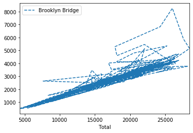

```python
print("Comparision of Total Bike movement vs the  Brooklyn Bridge")
data.plot(x="Total", y=["Brooklyn Bridge"], linestyle='dashed')
plt.show()
```

```
Comparision of Total Bike movement vs the  Manhattan Bridge
```

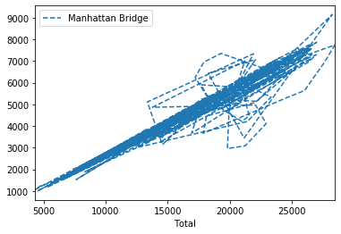

```python
print("Comparision of Total Bike movement vs the  Manhattan Bridge")
data.plot(x="Total", y=["Manhattan Bridge"], linestyle='dashed')
plt.show()
```

```
Comparision of Total Bike movement vs the  Williamsburg Bridge
```

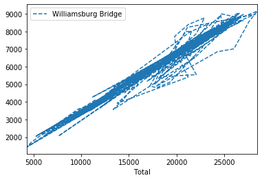

```python
print("Comparision of Total Bike movement vs the  Williamsburg Bridge")
data.plot(x="Total", y=["Williamsburg Bridge"], linestyle='dashed')
plt.show()
```

```
Comparision of Total Bike movement vs the  Queensboro Bridge
```

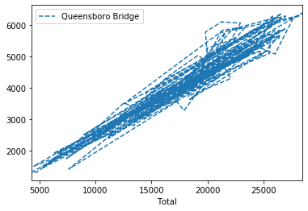

```python
print("Comparision of Total Bike movement vs the  Queensboro Bridge")
data.plot(x="Total", y=["Queensboro Bridge"], linestyle='dashed')
plt.show()
```

```
Comparative Graph of all this three brigde vs Total bike movement in month Apr
```

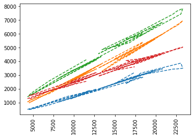

```
Comparative Graph of all this three brigde vs Total bike movement in month May
```

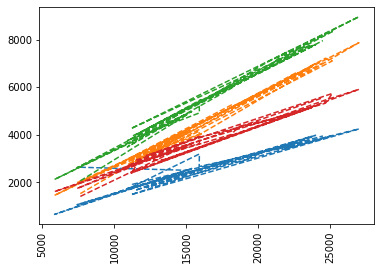

```
Comparative Graph of all this three brigde vs Total bike movement in month Jun
```

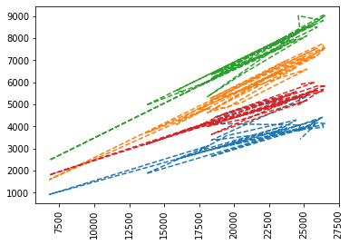

```
Comparative Graph of all this three brigde vs Total bike movement in month Jul
```

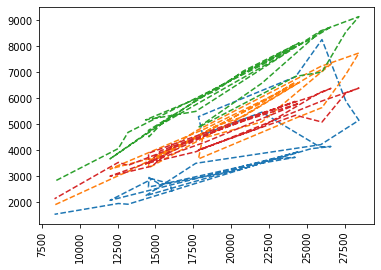

```
Comparative Graph of all this three brigde vs Total bike movement in month Aug
```

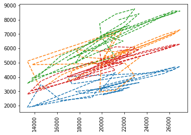

```
Comparative Graph of all this three brigde vs Total bike movement in month Sep
```

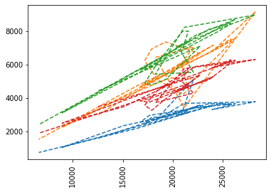

```
Comparative Graph of all this three brigde vs Total bike movement in month Oct
```

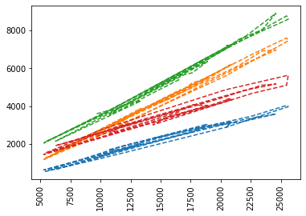

```python
for mth in data['Month'].unique():
    print("Comparative Graph of all this three brigde vs Total bike movement in month {}".format(mth))
    total=[]
    Brooklyn=[]
    Manhattan=[]
    Williamsburg=[]
    Queensboro=[]
    for i in range(len(data['Month'])):
        if data['Month'][i]==mth:
            total.append(data['Total'][data.index[i]])
            Brooklyn.append(data['Brooklyn Bridge'][data.index[i]])
            Manhattan.append(data['Manhattan Bridge'][data.index[i]])
            Williamsburg.append(data['Williamsburg Bridge'][data.index[i]])
            Queensboro.append(data['Queensboro Bridge'][data.index[i]])
    plt.plot(total,Brooklyn, linestyle='dashed')
    plt.plot(total,Manhattan, linestyle='dashed')
    plt.plot(total,Williamsburg, linestyle='dashed')
    plt.plot(total,Queensboro, linestyle='dashed')
    plt.xticks(rotation=90)
    plt.show()
```

```
Comparative Graph of all this three brigde vs Total bike movement in month ['Apr' 'May' 'Jun' 'Jul' 'Aug' 'Sep' 'Oct']
```

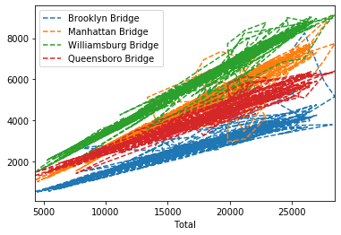

```
Total bike passed through 7 month in Brooklyn:  648570
Total bike passed through 7 month in Manhattan:  1081178
Total bike passed through 7 month in Williamsburg:  1318427
Total bike passed through 7 month in Queensboro:  920355
```

```python
print("Comparative Graph of all this three brigde vs Total bike movement in month {}".format(data['Month'].unique()))
data.plot(x="Total", y=["Brooklyn Bridge", "Manhattan Bridge", "Williamsburg Bridge",'Queensboro Bridge'], linestyle='dashed')
plt.show()
print("Total bike passed through 7 month in Brooklyn: ",sum(list(data['Brooklyn Bridge'])))
print("Total bike passed through 7 month in Manhattan: ",sum(list(data['Manhattan Bridge'])))
print("Total bike passed through 7 month in Williamsburg: ",sum(list(data['Williamsburg Bridge'])))
print("Total bike passed through 7 month in Queensboro: ",sum(list(data['Queensboro Bridge'])))
```

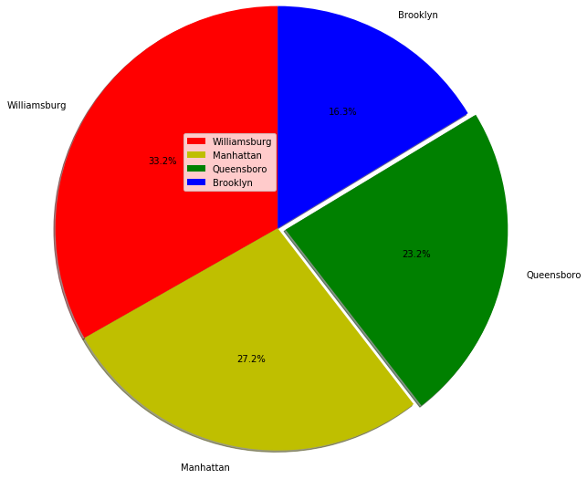

```python
activities = ['Williamsburg', 'Manhattan', 'Queensboro', 'Brooklyn']
slices = [1318427, 1081178, 920355, 648570]
colors = ['r', 'y', 'g', 'b']
plt.pie(slices, labels = activities, colors=colors,
        startangle=90, shadow = True, explode = (0, 0, 0.1, 0),
        radius = 2.8, autopct = '%1.1f%%')
plt.legend()
plt.show()
```

**Total bike passing through the bridges can be arranged in decreasing order as:**  
1.Total bike passed through 7 month in Williamsburg: 1318427  
2.Total bike passed through 7 month in Manhattan: 1081178  
3.Total bike passed through 7 month in Queensboro: 920355  
4.Total bike passed through 7 month in Brooklyn: 648570

**thus the Sensor can be installed on thsis three bridges:**

1. Williamsburg Bridge
2. Manhattan Bridge
3. Queensboro Bridge  
   Since this three bridge are responsible for most of the bike traffic , this can be used to install sensor

**2. Deployment of Police officer**

```python
data.head()
```

|  | Date | Day | High Temp (°F) | Low Temp (°F) | Precipitation | Brooklyn Bridge | Manhattan Bridge | Williamsburg Bridge | Queensboro Bridge | Total | Month |
| --- | --- | --- | --- | --- | --- | --- | --- | --- | --- | --- | --- |
| 0 | 1 | Friday | 78.1 | 66.0 | 0.01 | 1704 | 3126 | 4115 | 2552 | 11497 | Apr |
| 1 | 2 | Saturday | 55.0 | 48.9 | 0.15 | 827 | 1646 | 2565 | 1884 | 6922 | Apr |
| 2 | 3 | Sunday | 39.9 | 34.0 | 0.09 | 526 | 1232 | 1695 | 1306 | 4759 | Apr |
| 3 | 4 | Monday | 44.1 | 33.1 | 0.47 | 521 | 1067 | 1440 | 1307 | 4335 | Apr |
| 4 | 5 | Tuesday | 42.1 | 26.1 | 0.00 | 1416 | 2617 | 3081 | 2357 | 9471 | Apr |

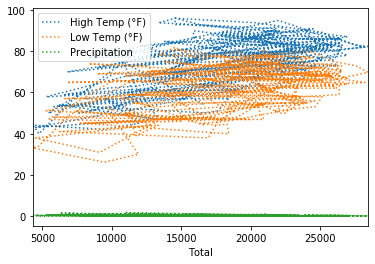

```python
data.plot(x="Total", y=["High Temp (°F)","Low Temp (°F)","Precipitation"], linestyle='dotted')
plt.show()
```

Thus we can draw conclusion as:  
When the temperature is low (below 70) ,bike traffic is low  
when the temperature is median(between range 70 to 100 ), bike traffic is high

Thus  
**Next Day Weather forcast can be used to predict the number of bicyclists on that day**  
Accordingly police officer can be deployed

**3. Prediction of Rainy Day baed on Bicyclist**

```python
T=list(data['Total'])
T.sort()
P=list(data['Precipitation'])
P.sort()
print(T[0],T[-1],T[80])
```

```
4335 28437 17570
```

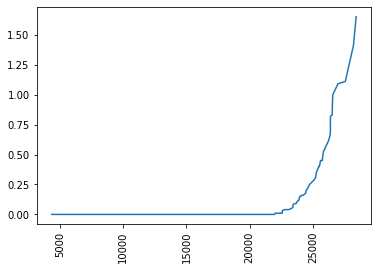

```python
plt.plot(T,P)
plt.xticks(rotation=90)
plt.xticks(ticks=None, labels=None)
plt.show()
```